# Scratch

Julian Hatwell

25 March 2016

## 6.1

The JobSat data in vcdExtra gives a 4 × 4 table recording job satisfaction in relation to income.

```
##         satisfaction
## income   VeryD LittleD ModerateS VeryS
##   < 15k      1       3        10     6
##   15-25k     2       3        10     7
##   25-40k     1       6        14    12
##   > 40k      0       1         9    11
```

1. Carry out a simple correspondence analysis on this table. How much of the inertia is accounted for by a one-dimensional solution? How much by a two-dimensional solution?

```
##
## Principal inertias (eigenvalues):
##
##  dim    value      %   cum%   scree plot
##  1      0.047496  76.4  76.4  *******************
##  2      0.012248  19.7  96.1  *****
##  3      0.002397   3.9 100.0  *
##         -------- -----
##  Total: 0.062141 100.0
##
##
## Rows:
##     name   mass  qlt  inr    k=1 cor ctr    k=2 cor ctr
## 1 |  15k |  208  658   81 | -126 658  70 |    4   1   0 |
## 2 | 1525 |  229  977  247 | -208 647 209 | -148 329 412 |
## 3 | 2540 |  344  956  114 |  -35  59   9 |  136 897 519 |
## 4 |  40k |  219 1000  558 |  393 976 712 |  -62  24  69 |
##
## Columns:
##     name   mass  qlt  inr    k=1 cor ctr    k=2 cor ctr
## 1 | VryD |   42  985  384 | -662 766 385 | -354 219 427 |
## 2 | LttD |  135  990  294 | -289 621 239 |  223 369 549 |
## 3 | MdrS |  448  334   31 |  -31 233   9 |  -21 101  16 |
## 4 | VryS |  375  967  292 |  216 961 367 |  -16   6   8 |
```

*76.4% of the inertia is accounted for by the first dimension and a total of 96.1% when the second dimension is included. A property of the correspondance analysis is that the solutions are nested, so the one dimensional solution is identical to the first dimension of higher dimensional solutions.*

2. Plot the 2D CA solution. To what extent can you consider the association between job satisfaction and income “explained” by the ordinal nature of these variables?

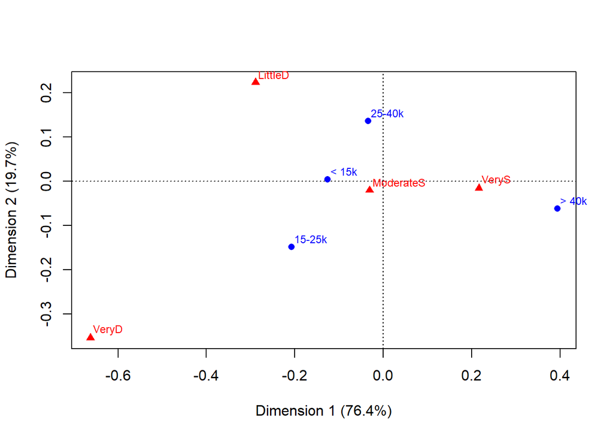

*The levels of job satisfaction are only partly explained by the ordinal nature of the variables. The first dimension accounts for 76% of the association and the points from each variable do not project along this line in the same order. Only the association between >40K salaries and very satisfied is absolutely clear.*

*The second dimension is less easy to inerpret though it assists in visualising that there is a stronger link between very disatisfied and 15-25K, rather than the lowest salary band. Likewise for 25-40K and Little disatisfied. In fact there is a stronger association between Moderately satisfied and the lowest salary band than either intermediate band.*

## 6.2

Refer to Exercise 5.1 in Chapter 5. Carry out a simple correspondence analysis on the 4 × 5 table criminal from the logmult package.

```
##       Age
## Year    15  16  17  18  19
##   1955 141 285 320 441 427
##   1956 144 292 342 441 396
##   1957 196 380 424 462 427
##   1958 212 424 399 442 430
```

1. What percentages of the Pearson χ2 for association are explained by the various dimensions?

| dims | X2explained |
| --- | --- |
| dim 1 | 90.34 |
| dim 2 | 8.97 |
| dim 3 | 0.69 |

2. Plot the 2D correspondence analysis solution. Describe the pattern of association between year and age.

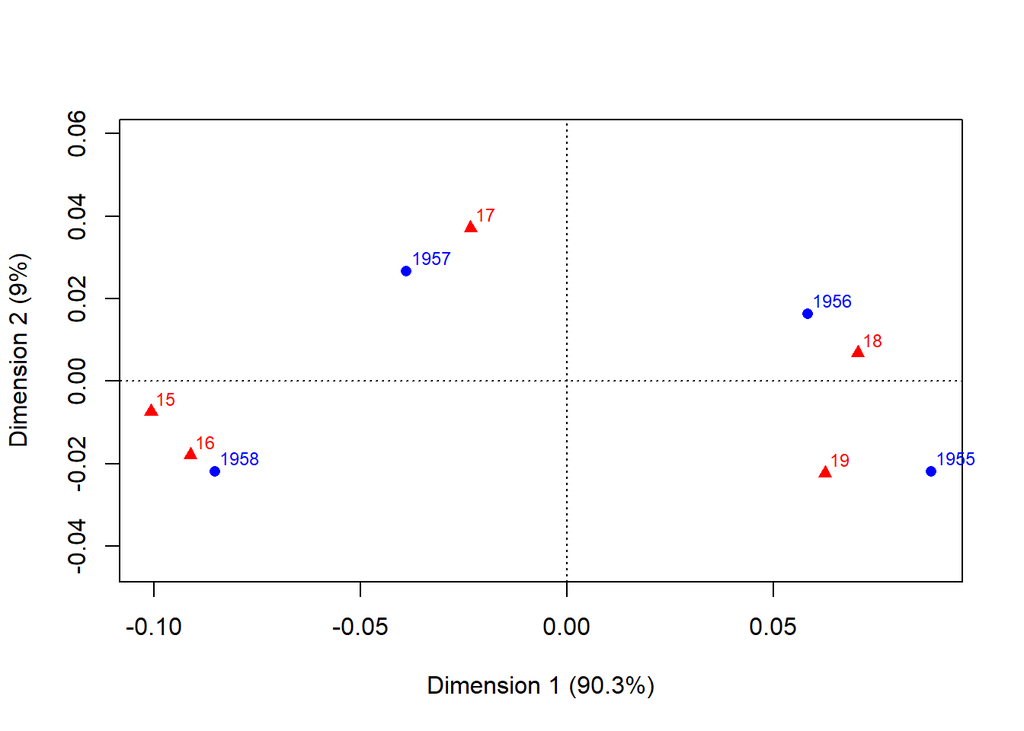

*Most of the association (>90%) is along the first dimension. The association between age and year is clear from the plot with youngest individuals located very close to 1958 and progressively older for the previous years. This corresponds to the shift in centre of mass for the age group towards releasing younger individuals in later years.*

## 6.3

Refer to Exercise 5.2 for a description of the AirCrash data from the vcdExtra package. Carry out a simple correspondence analysis on the 5 × 5 table of Phase of the flight and Cause of the crash.

```
##
## Principal inertias (eigenvalues):
##
##  dim    value      %   cum%   scree plot
##  1      0.169464  77.1  77.1  *******************
##  2      0.046484  21.1  98.2  *****
##  3      0.003870   1.8 100.0
##  4      2.1e-050   0.0 100.0
##         -------- -----
##  Total: 0.219838 100.0
##
##
## Rows:
##     name   mass  qlt  inr    k=1 cor ctr    k=2 cor ctr
## 1 | tkff |  125  999  232 | -352 302  91 |  534 697 765 |
## 2 | lndn |  368 1000  356 | -429 866 400 | -168 134 225 |
## 3 | enrt |  499 1000  381 |  410 999 494 |  -13   1   2 |
## 4 | stnd |    1  839    6 | 1407 830   6 |  143   9   0 |
## 5 | unkn |    8  347   25 | -448 277   9 |  225  70   8 |
##
## Columns:
##     name   mass  qlt  inr    k=1 cor ctr    k=2 cor ctr
## 1 | unkn |   79  752   21 |  206 716  20 |  -46  36   4 |
## 2 | hmnr |  498  989  163 | -258 920 195 |   70  68  53 |
## 3 | mchn |  132  918   87 |  129 114  13 |  342 804 332 |
## 4 | wthr |  117  983  201 | -391 403 105 | -470 581 553 |
## 5 | crmn |  175 1000  527 |  804 977 667 | -125  23  58 |
```

1. What percentages of the Pearson χ2 for association are explained by the various dimensions?

| dims | X2explained |
| --- | --- |
| dim 1 | 77.09 |
| dim 2 | 21.14 |
| dim 3 | 1.76 |
| dim 4 | 0.01 |

2. Plot the 2D correspondence analysis solution. Describe the pattern of association between phase and cause. How would you interpret the dimensions?

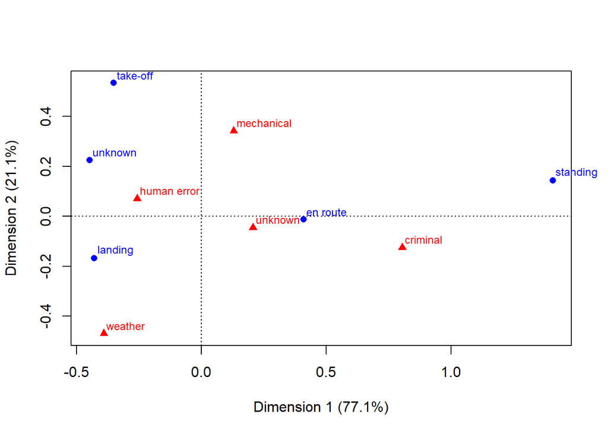

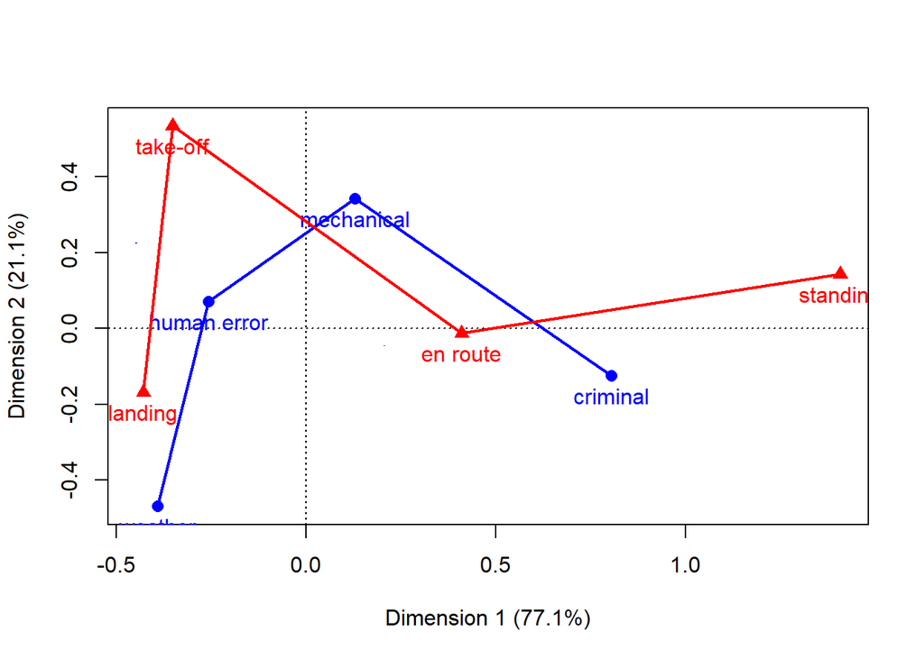

*The second plot has the points for unknown removed as they hinder the interpretation.*

*The first dimension seems to separate take-off and landing from the other two phases. This could be thought of as differences between engagement by the flight crew, in particular the pilots.*

*The second dimension appears to separate human error and mechanical from weather and criminal. Perhaps this could be seen as preventable vs unforeseeable types of events, but it’s a fairly vague interpretation.*

3. The default plot method uses map=“symmetric” with points for both rows and columns. Try using map=“symbiplot” with vectors (arrows=) for either rows or columns. (Read help (plot.ca) for a description of these options.)

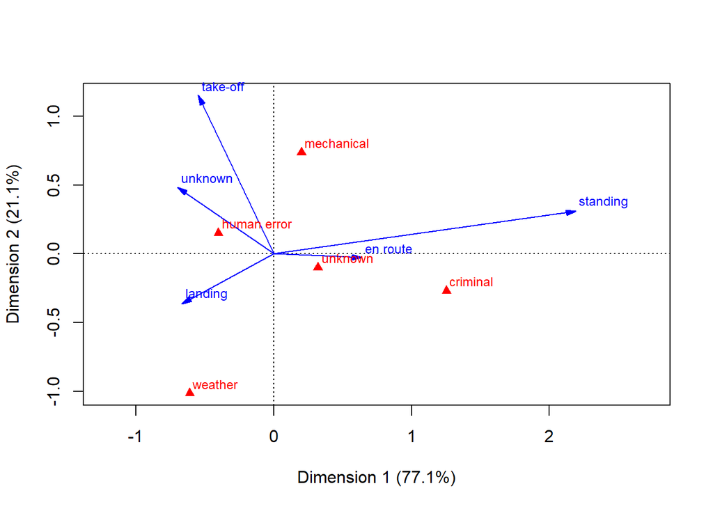

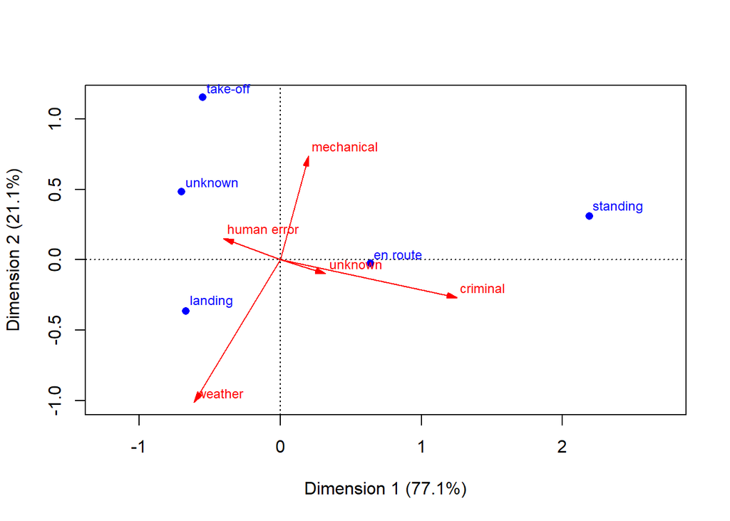

*Of these, the first plot at first glance emphasises the unknown causes occuring en route. The second plot emphasises a strong link between weather cause and langing phase, compared to mechanical and human error with landing phase.*

## 6.4

The data set caith in MASS gives a classic table tabulating hair color and eye color of people in Caithness, Scotland, originally from Fisher (1940).

1. Carry out a simple correspondence analysis on this table. How many dimensions seem necessary to account for most of the association in the table?

| dims | X2explained |
| --- | --- |
| dim 1 | 86.56 |
| dim 2 | 13.07 |
| dim 3 | 0.37 |

*A single dimension explains most of the variation and the first two explain all of it minus a tiny fraction.*

2. Plot the 2D solution. The interpretation of the first dimension should be obvious; is there any interpretation for the second dimension?

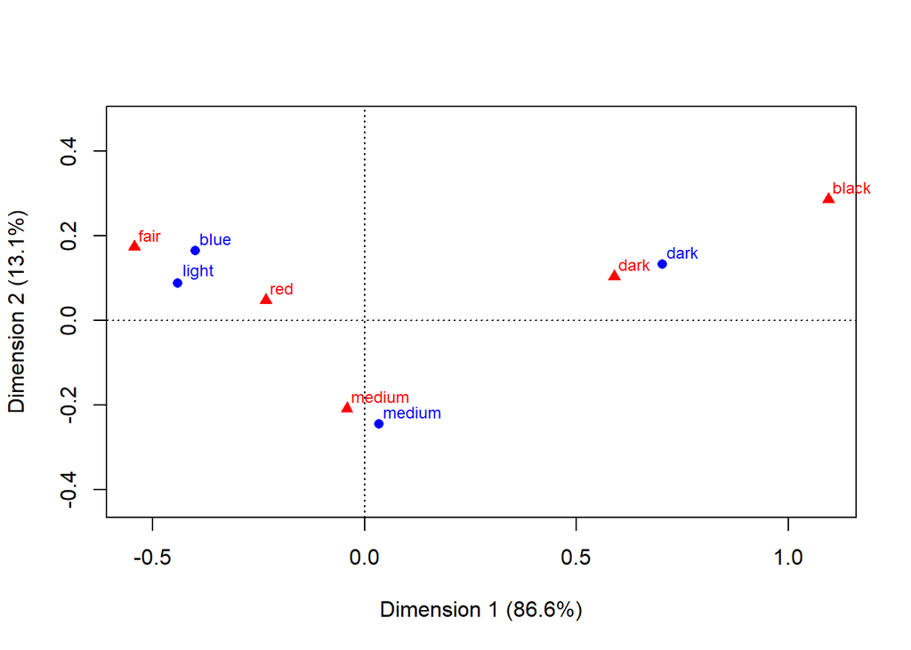

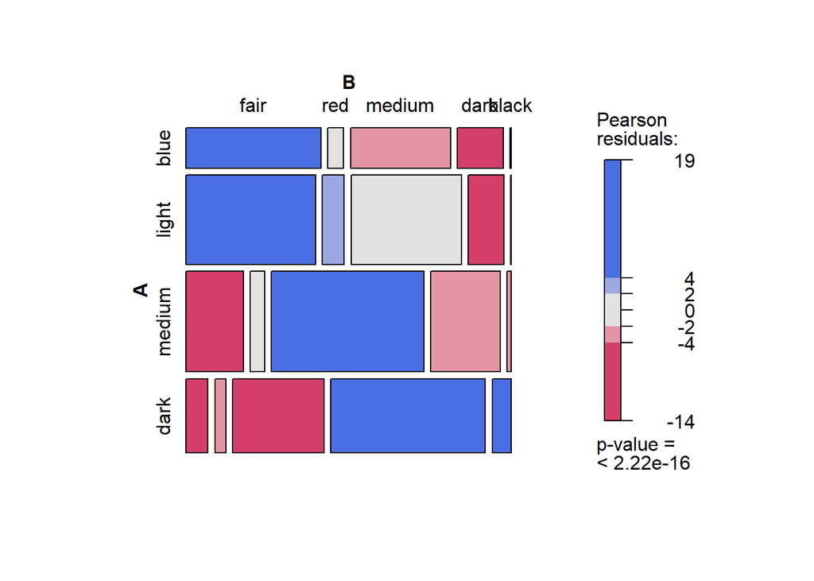

*The second dimension separates medium from all the others. It’s not obvious but there must be something different about the classification as medium on both categories.*

*Reviewing the mosaic plot for this data helps to visualise that medium is over represented. Perhaps, given the amiguity of the descriptor, the people who originally collected the data had a tendency to score medium observations over the others when they weren’t sure.*

## 6.5

The same data, plus a similar table for Aberdeen, are given as a three-way table as HairEyePlace in vcdExtra.

1. Carry out a similar correspondence analysis to the last exercise for the data from Aberdeen. Comment on any differences in the placement of the category points.

| dims | X2explained |
| --- | --- |
| dim 1 | 87.93 |
| dim 2 | 11.78 |
| dim 3 | 0.30 |

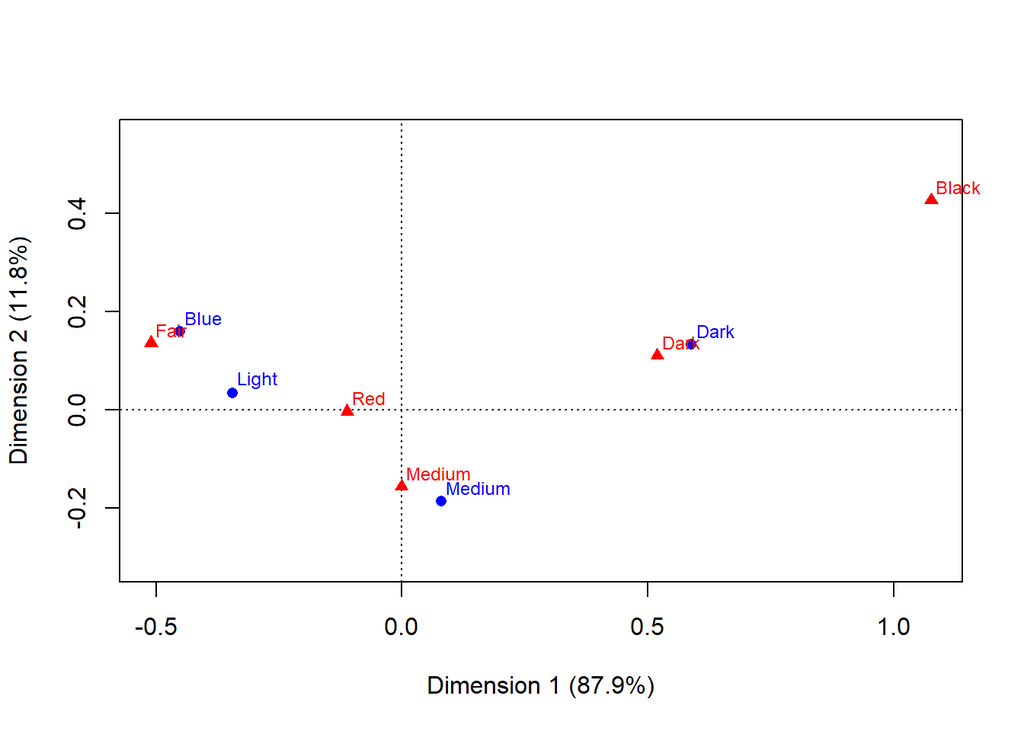

2. Analyze the three-way table, stacked to code hair color and place interactively, i.e., for the loglinear model [Hair Place][Eye]. What does this show?

| dims | X2explained |
| --- | --- |
| dim 1 | 87.26 |
| dim 2 | 12.27 |
| dim 3 | 0.47 |

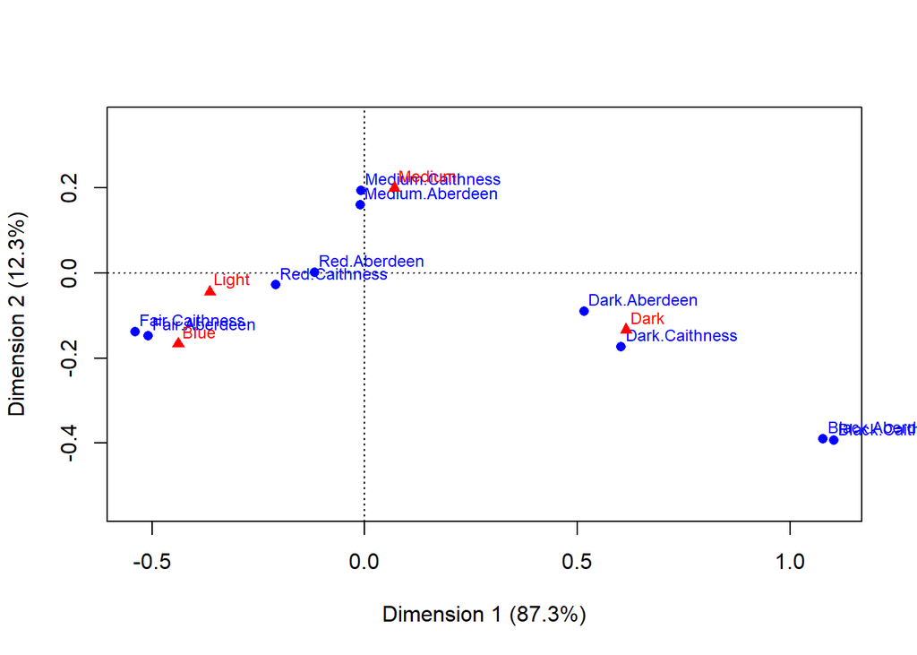

*This approach superimposes the two places on the same plot and appears to highlight the overall similarities. The distribution of red and dark hair differs slightly. Red hair being more common in Aberdeen (closer to the origin).*

## 6.6

The data set Gilby in vcdExtra gives a classic (but now politically incorrect) 6 × 4 table of English schoolboys classified according to their clothing and their teacher’s rating of “dullness” (lack of intelligence).

1. Compute and plot a correspondence analysis for this data. Write a brief description and interpretation of these results.

```
##                  Clothing
## Dullness          V.Well clad Well clad Passable Insufficient
##   Ment. defective          33        41       39           17
##   Slow                     48       100       58           13
##   Slow Intell             113       202       70           22
##   Fairly Intell           209       255       61           10
##   Capable                 194       138       33           10
##   V.Able                   39        15        4            1
```

| dims | X2explained |
| --- | --- |
| dim 1 | 78.29 |
| dim 2 | 19.85 |
| dim 3 | 1.86 |

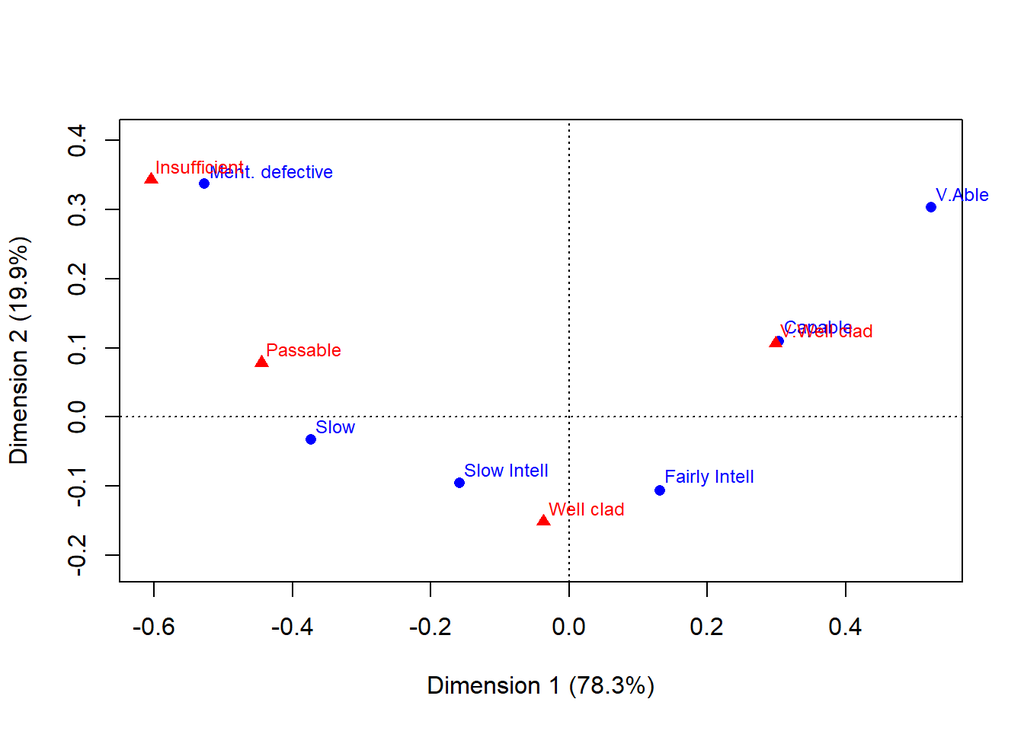

*The first dimension explains 78% of the $\chi^2$ statistic and both categories line up ordinally from left to right projected onto this line.*

*The variables are also well separated between the centre and the extremes when looking at the second dimension, giving the plot points a very clear smile pattern.*

*Without more information, it’s difficult to guess at an explanation for this pattern.*

2. Make an analogous mosaic plot of this table. Interpret this in relation to the correspondence analysis plot.

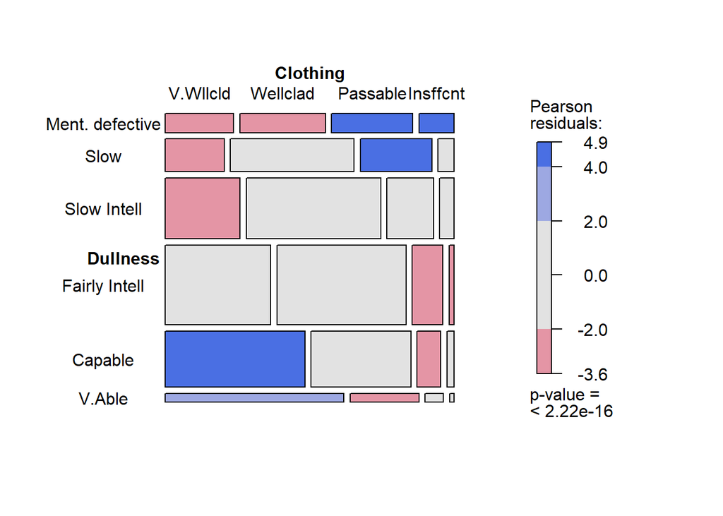

*The classic opposite corner pattern is evident although on close inspection it is not fully reaching into the botton right corner. The extremes of Insufficiently well clad and Very Able intelligence do not follow the trend. Clearly there is a more complicated pattern which may warrant further investigation.*

## 6.7

For the mental health data analyzed in Example 6.2, construct a shaded sieve diagram and mosaic plot. Compare these with the correspondence analysis plot shown in Figure 6.2. What features of the data and the association between SES and mental health status are shown in each?

*Reproducing the example first*

```
##
## Principal inertias (eigenvalues):
##
##  dim    value      %   cum%   scree plot
##  1      0.026025  93.9  93.9  ***********************
##  2      0.001379   5.0  98.9  *
##  3      0.000298   1.1 100.0
##         -------- -----
##  Total: 0.027702 100.0
##
##
## Rows:
##     name   mass  qlt  inr    k=1 cor ctr    k=2 cor ctr
## 1 |    1 |  158  978  193 | -181 967 199 |  -19  11  42 |
## 2 |    2 |  148  979  187 | -185 975 194 |  -12   4  14 |
## 3 |    3 |  173  973   26 |  -59 852  23 |  -22 120  62 |
## 4 |    4 |  231  938   16 |    9  40   1 |   42 898 297 |
## 5 |    5 |  160  996  169 |  165 932 168 |   44  65 220 |
## 6 |    6 |  131 1000  409 |  288 955 416 |  -62  44 364 |
##
## Columns:
##     name   mass  qlt  inr    k=1 cor ctr    k=2 cor ctr
## 1 | Well |  185  992  454 | -260 990 479 |   12   2  20 |
## 2 | Mild |  363  785   24 |  -30 479  12 |   24 306 147 |
## 3 | Mdrt |  218  998   40 |   14  40   2 |  -70 958 773 |
## 4 | Impr |  234  996  482 |  237 989 507 |   19   6  61 |
```

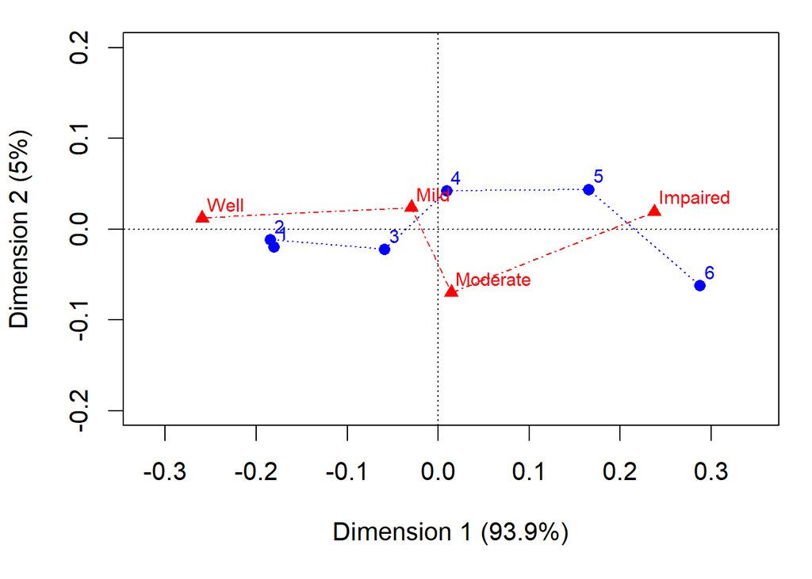

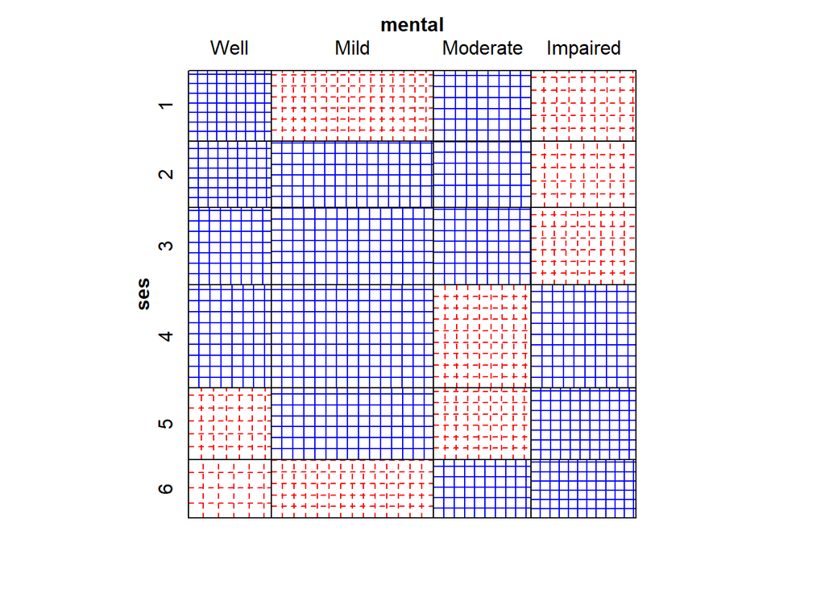

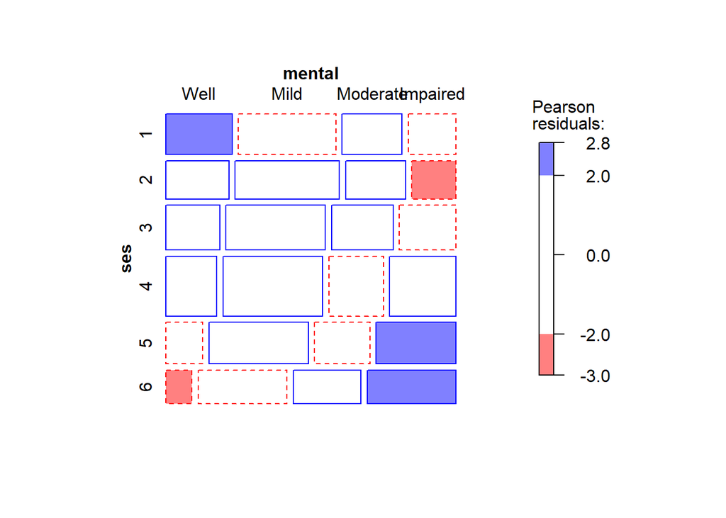

*Looking at the three plots together, one interpretation would be that the data follows a classic opposite corner pattern. There is additional complexity in the moderate mental health category where the pattern doesn’t hold in the strucplots and the lines cross in the correspondence plot. There seems to be room for further investigation of this factor.*

## 6.8

Simulated data are often useful to help understand the connections between data, analysis methods, and associated graphic displays. Section 6.3.1 illustrated interactive coding in R, using a simulated 4-way table of counts of pets, classified by age, color, and sex, but with no associations because the counts had a constant Poisson mean, λ = 15.

1. Re-do this example, but in the call to rpois(), specify a non-negative vector of Poisson means to create some associations among the table factors.

*Recalling the example with some changes*

```
##              Pet   dog       cat      bird
##              Age young old young old young old
## Color Sex
## black male          23  17     2  15     6   5
##       female        12  11    14   2     0   2
## white male          26  25    30  12     4   3
##       female         7  13     7   9     2  10
```

```
##               Pet.Age
## Color.Sex      dog.young dog.old cat.young cat.old bird.young bird.old
##   black.male          23      17         2      15          6        5
##   black.female        12      11        14       2          0        2
##   white.male          26      25        30      12          4        3
##   white.female         7      13         7       9          2       10
```

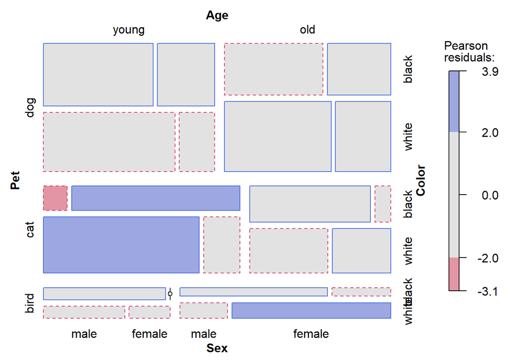

2. Use CA methods to determine if and how the structure you created in the data appears in the results.

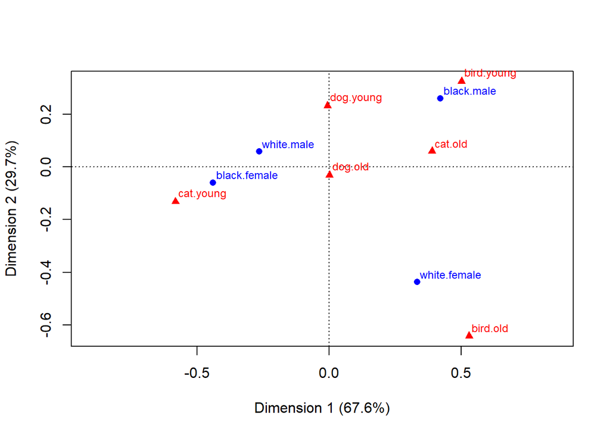

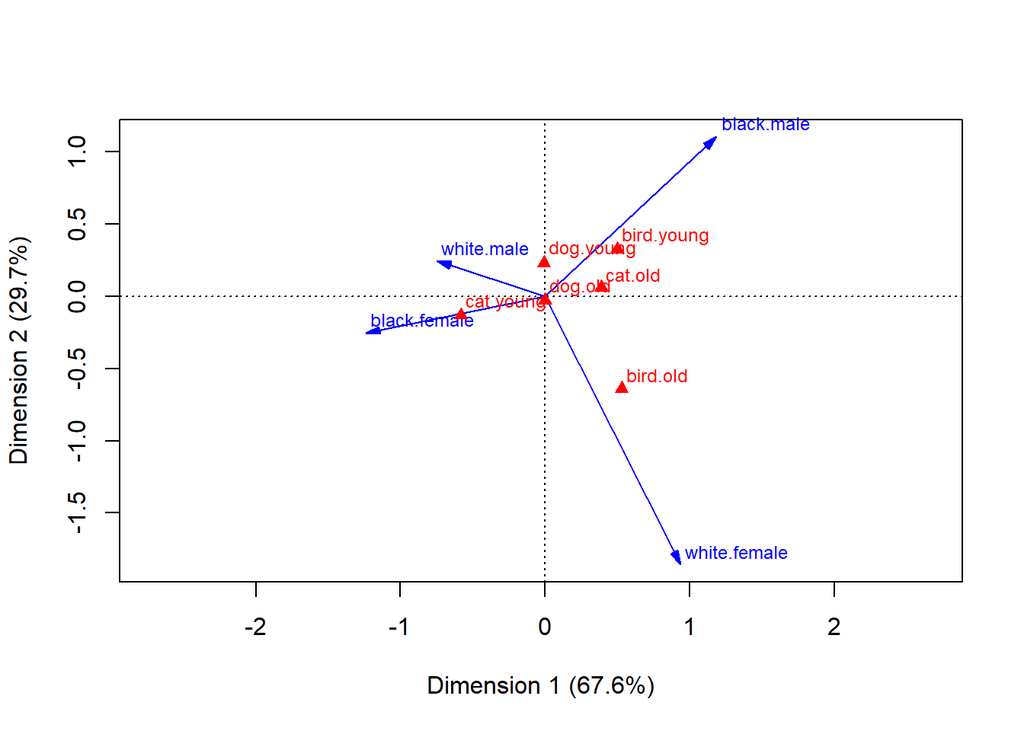

*This alternative uses colprincipal scaling and vectors to show the dominant effects.*

```
##               Pet
## Age.Sex        dog cat bird
##   young.male    49  32   10
##   young.female  19  21    2
##   old.male      42  27    8
##   old.female    24  11   12
```

```
##
## Principal inertias (eigenvalues):
##
##  dim    value      %   cum%   scree plot
##  1      0.049965  92.7  92.7  ***********************
##  2      0.003906   7.3 100.0  **
##         -------- -----
##  Total: 0.053871 100.0
##
##
## Rows:
##        name   mass  qlt  inr    k=1 cor  ctr    k=2 cor  ctr
## 1 |    yngm |  354 1000   15 |   30 398    6 |  -37 602  125 |
## 2 |    yngf |  163 1000  354 |  324 900  344 |  108 100  490 |
## 3 |    oldm |  300 1000   25 |   43 398   11 |  -52 602  210 |
## 4 |    oldf |  183 1000  605 | -418 979  639 |   61  21  175 |
## 5 | (*)blck | <NA> 1000 <NA> |  -42 126 <NA> | -110 874 <NA> |
## 6 | (*)whit | <NA> 1000 <NA> |   31 126 <NA> |   81 874 <NA> |
##
## Columns:
##     name   mass  qlt  inr    k=1 cor ctr    k=2 cor ctr
## 1 |  dog |  521 1000   38 |  -20 102   4 |  -60 898 474 |
## 2 |  cat |  354 1000  321 |  213 926 321 |   60  74 325 |
## 3 | bird |  125 1000  641 | -521 977 675 |   79  23 200 |
```

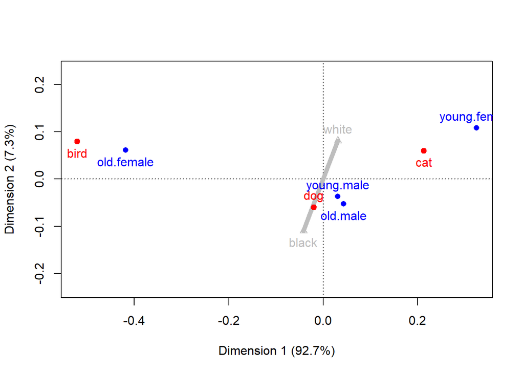

*Having a go at working through the supplementary row technique. This may not be the best example, but there is some utility, given a bit of trial and error (exploratory work).*

## 6.9

The TV data was analyzed using CA in Example 6.4, ignoring the variable Time. Carry out analyses of the 3-way table, reducing the number of levels of Time to three hourly intervals as shown below.

```
##              Day Monday Tuesday Wednesday Thursday Friday
## Time Network
## 8    ABC            536     861       744      735   1119
##      CBS           1167     646       550      680    509
##      NBC            858    1090       512     1927    823
## 9    ABC           1401    1205      1022      682    907
##      CBS            967     959       409      385    544
##      NBC            946     890       831     1858    590
## 10   ABC            910    1044       668      349    711
##      CBS            789     798       324      270    426
##      NBC            825     588       869     2101    585
```

1. Use the stacking approach (Section 6.3) to perform a CA of the table with Network and Time coded interactively. You can create this using the as.matrix () method for a “Structable” object.
2. What loglinear model is analyzed by this approach?

```
## [1] "[Time,Network] [Day]"
```

```
## ~Time:Network + Day
```

3. Plot the 2D solution. Compare this to the CA plot of the two-way table in Figure 6.4.

*First to replot the example given.*

```
##            Network
## Day          ABC  CBS  NBC
##   Monday    2847 2923 2629
##   Tuesday   3110 2403 2568
##   Wednesday 2434 1283 2212
##   Thursday  1766 1335 5886
##   Friday    2737 1479 1998
```

```
##
##  Principal inertias (eigenvalues):
##            1        2
## Value      0.081934 0.010513
## Percentage 88.63%   11.37%
##
##
##  Rows:
##           Monday  Tuesday Wednesday  Thursday    Friday
## Mass    0.223318 0.214863  0.157644  0.238952  0.165222
## ChiDist 0.243954 0.182506  0.144175  0.505601  0.215013
## Inertia 0.013290 0.007157  0.003277  0.061084  0.007638
## Dim. 1  0.676891 0.633511  0.229080 -1.765205  0.595602
## Dim. 2  1.445722 0.201166 -1.252294  0.177694 -1.277814
##
##
##  Columns:
##               ABC      CBS       NBC
## Mass     0.342834 0.250545  0.406621
## ChiDist  0.257545 0.290254  0.345714
## Inertia  0.022740 0.021108  0.048599
## Dim. 1   0.804089 0.859817 -1.207741
## Dim. 2  -1.127076 1.500670  0.025613
```

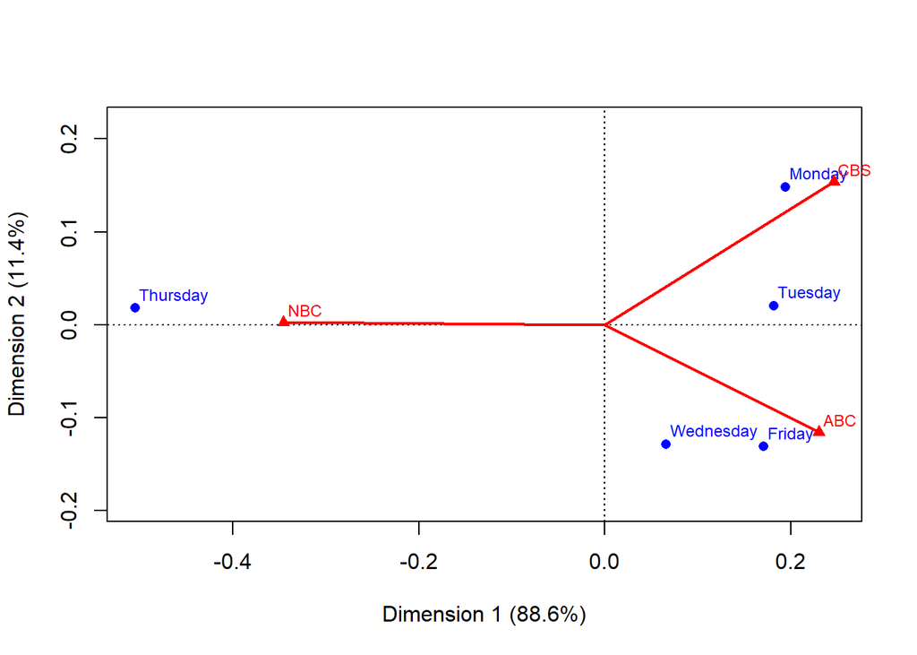

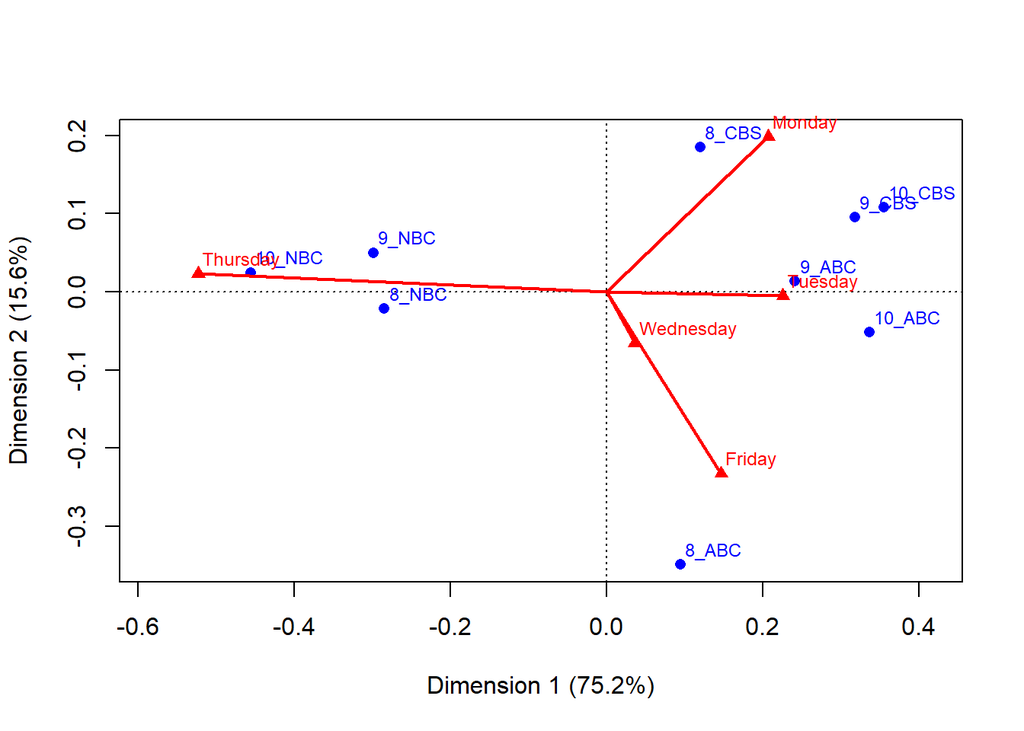

*Lines have been added to practise the technique even though they highlight a different category (Day).*

*Now it’s possible to drill into the scheduling and see Monday 8pm CBS and Friday 8pm ABC, with a more mixed viewing on other times/days.*

*Also the thursday night effect of viewers increasing during the hours from 8-11pm is visible.*

4. Carry out an MCA analysis using mjca() of the three-way table TV3. Plot the 2D solution, and compare this with both the CA plot and the solution for the stacked three-way table.

| dims | X2explained |
| --- | --- |
| dim 1 | 64.0 |
| dim 2 | 8.1 |
| dim 3 | 3.1 |
| dim 4 | 0.0 |

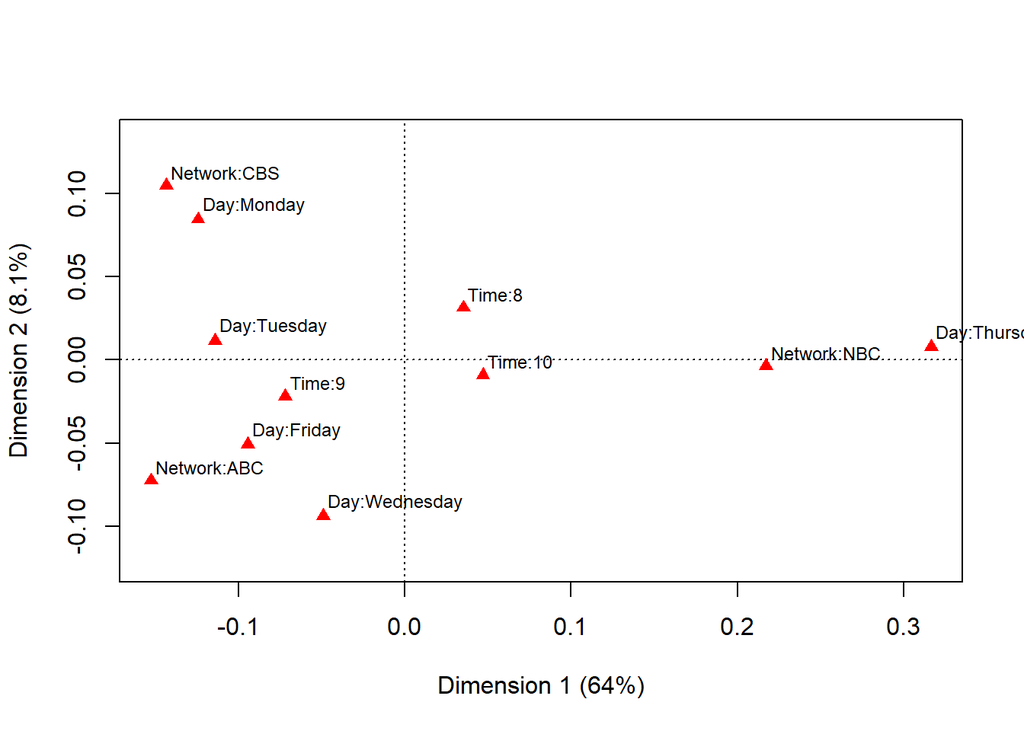

*The default plot doesn’t provide any clarity as all the points use the same symbols and colours.*

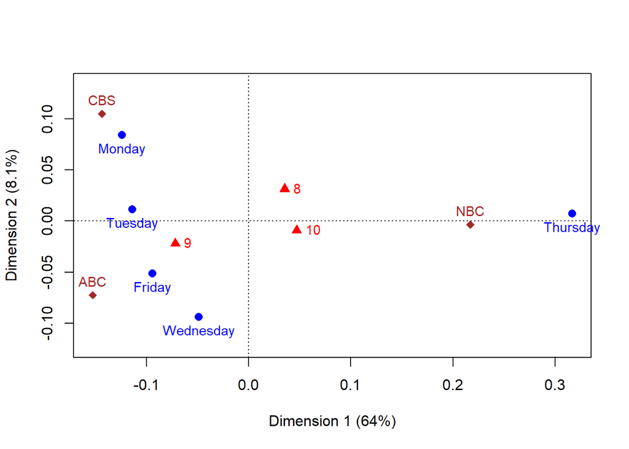

*This plot is using some customisation to improve the visual language but it hasn’t added any useful information.*

## 6.10

Refer to the MCA analysis of the PreSex data in Example 6.8. Use the stacking approach to analyze the stacked table with the combinations of premarital and extramarital sex in the rows and the combinations of gender and marital status in the columns. As suggested in the exercise above, you can use as.matrix (structable()) to create the stacked table.

```
##
## Principal inertias (eigenvalues):
##
##  dim    value      %   cum%   scree plot
##  1      0.483938  30.5  30.5  ********
##  2      0.329524  20.7  51.2  *****
##  3      0.270085  17.0  68.2  ****
##  4      0.230691  14.5  82.7  ****
##  5      0.181441  11.4  94.2  ***
##  6      0.092625   5.8 100.0  *
##         -------- -----
##  Total: 1.588303 100.0
##
##
## Columns:
##                   name   mass  qlt  inr     k=1 cor ctr    k=2 cor ctr
## 1 |          P_E:No_No |  354  818   53 |   440 818 141 |  -11   1   0 |
## 2 |         P_E:No_Yes |   29  673  154 | -1008 122  62 | 2138 551 408 |
## 3 |         P_E:Yes_No |   87  445  138 |  -942 353 160 | -480  92  61 |
## 4 |        P_E:Yes_Yes |   29  309  155 | -1512 268 137 | -588  41  30 |
## 5 |   M_G:Divorced_Men |   83  638  145 | -1271 587 279 | -377  52  36 |
## 6 | M_G:Divorced_Women |  155  600  111 |  -149  20   7 |  813 580 311 |
## 7 |    M_G:Married_Men |   90  218  130 |   -42   1   0 | -706 217 136 |
## 8 |  M_G:Married_Women |  171  602  114 |   777 571 214 | -180  31  17 |
```

1. What loglinear model is analyzed by this approach? Which associations are included and which are excluded in this analysis?

```
## [MaritalStatus,Gender][PremaritalSex,ExtramaritalSex]
```

*This approach will not provide information about joint associations between any one category and the other three or the mutual independence model.*

2. Plot the 2D CA solution for this analysis. You might want to draw lines connecting some of the row points or column points to aid in interpretation.

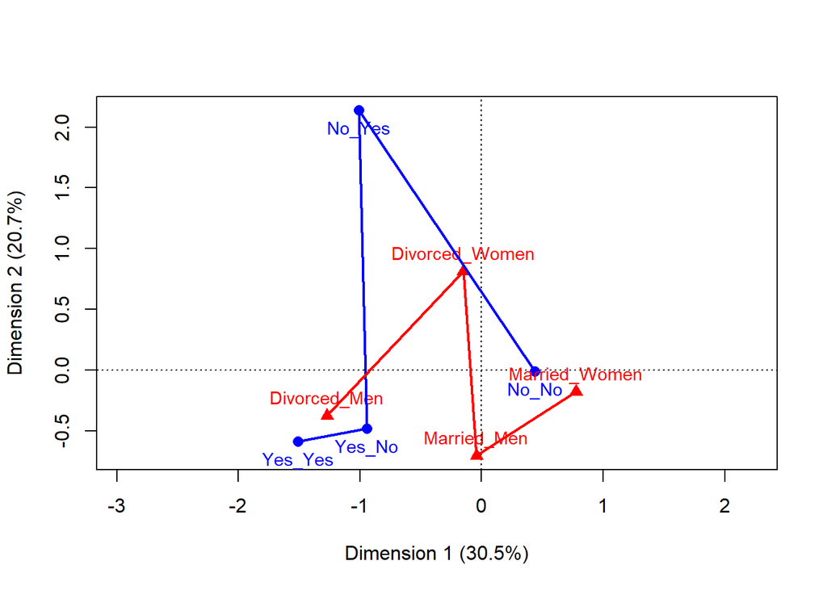

3. How does this analysis differ from the MCA analysis shown in Figure 6.10?

*The figure in the book considers the isolated effect of each variable on the others. This figure encourages the viewer to look for relationships between all four variables at the same time.*

## 6.11

Refer to Exercise 5.10 for a description of the Vietnam data set in vcdExtra.

1. Using the stacking approach, carry out a correspondence analysis corresponding to the loglinear model [R][YS], which asserts that the response is independent of the combinations of year an sex.

```
##         response
## sex_year   A   B   C   D
##      F_1  13  19  40   5
##      F_2   5   9  33   3
##      F_3  22  29 110   6
##      F_4  12  21  58  10
##      F_5  19  27 128  13
##      M_1 175 116 131  17
##      M_2 160 126 135  21
##      M_3 132 120 154  29
##      M_4 145  95 185  44
##      M_5 118 176 345 141
```

```
##
## Principal inertias (eigenvalues):
##
##  dim    value      %   cum%   scree plot
##  1      0.085680  73.6  73.6  ******************
##  2      0.027881  23.9  97.5  ******
##  3      0.002854   2.5 100.0  *
##         -------- -----
##  Total: 0.116415 100.0
##
##
## Rows:
##      name   mass  qlt  inr    k=1 cor ctr    k=2 cor ctr
## 1  |  F_1 |   24  818   13 | -167 452   8 | -150 367  20 |
## 2  |  F_2 |   16  995   35 | -407 647  31 | -299 349  51 |
## 3  |  F_3 |   53  999  112 | -334 453  69 | -367 547 256 |
## 4  |  F_4 |   32  982   37 | -344 887  44 | -113  95  15 |
## 5  |  F_5 |   59  994  153 | -453 686 143 | -304 309 197 |
## 6  |  M_1 |  139  997  181 |  386 986 242 |  -41  11   8 |
## 7  |  M_2 |  140  984  131 |  326 982 175 |  -15   2   1 |
## 8  |  M_3 |  138  904   40 |  175 904  49 |   -4   0   0 |
## 9  |  M_4 |  149  383   23 |   81 372  11 |   14  11   1 |
## 10 |  M_5 |  248 1000  276 | -281 608 228 |  225 391 451 |
##
## Columns:
##     name   mass  qlt  inr    k=1 cor ctr    k=2 cor ctr
## 1 |    A |  255  985  381 |  414 985 509 |   -1   0   0 |
## 2 |    B |  235  720   60 |  135 608  50 |   58 112  28 |
## 3 |    C |  419  999  283 | -247 773 298 | -133 226 267 |
## 4 |    D |   92  995  276 | -366 383 143 |  463 612 705 |
```

2. Construct an informative 2D plot of the solution, and interpret in terms of how the response varies with year for males and females.

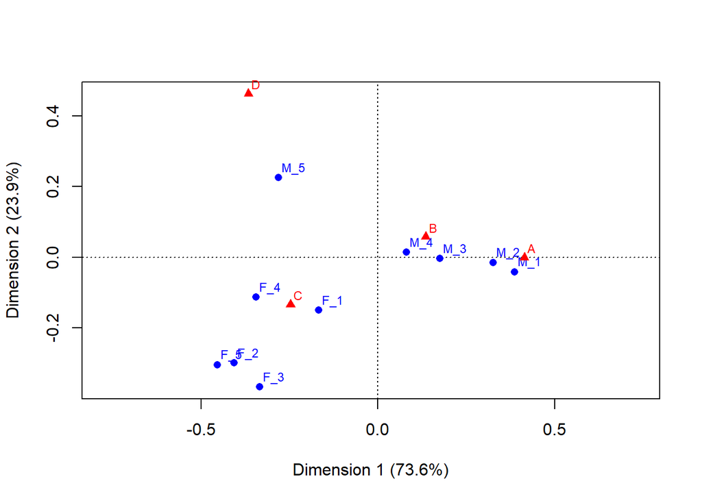

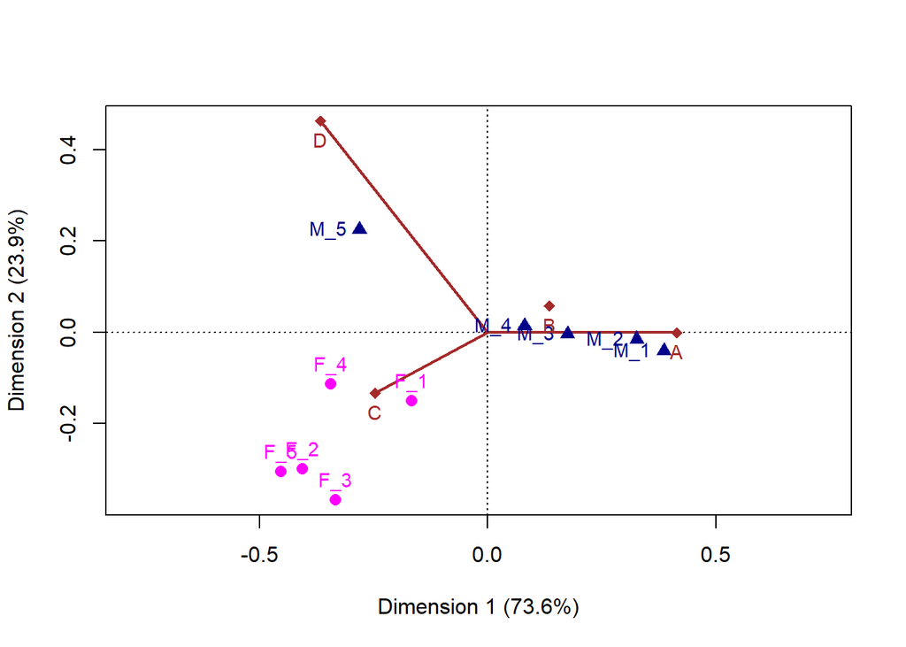

3. Use mjca () to carry out an MCA on the three-way table. Make a useful plot of the solution and interpret in terms of the relationship of the response to year and sex.

```
##
## Principal inertias (eigenvalues):
##
##  dim    value      %   cum%   scree plot
##  1      0.028219  65.1  65.1  ********************
##  2      0.007445  17.2  82.3  *****
##  3      0.000380   0.9  83.2
##  4      1e-06000   0.0  83.2
##         -------- -----
##  Total: 0.043317
##
##
## Columns:
##            name   mass  qlt  inr    k=1 cor ctr    k=2 cor ctr
## 1  | response:A |   85  818   95 | -260 797 203 |   42  21  20 |
## 2  | response:B |   78  663   93 |  -93 662  24 |    4   1   0 |
## 3  | response:C |  140  856   74 |  182 817 164 |   39  38  29 |
## 4  | response:D |   31  736  113 |  125 107  17 | -304 629 381 |
## 5  | sex:Female |   62  853  105 |  328 749 235 |  122 104 123 |
## 6  |   sex:Male |  272  853   24 |  -74 749  53 |  -28 104  28 |
## 7  |     year:1 |   55  856  103 | -201 780  78 |   63  76  29 |
## 8  |     year:2 |   52  948  104 | -231 948  99 |    6   1   0 |
## 9  |     year:3 |   64  899  100 |  104 306  24 |  145 592 179 |
## 10 |     year:4 |   60   55   99 |  -12  44   0 |   -6  10   0 |
## 11 |     year:5 |  102  756   88 |  167 490 102 | -123 267 210 |
```

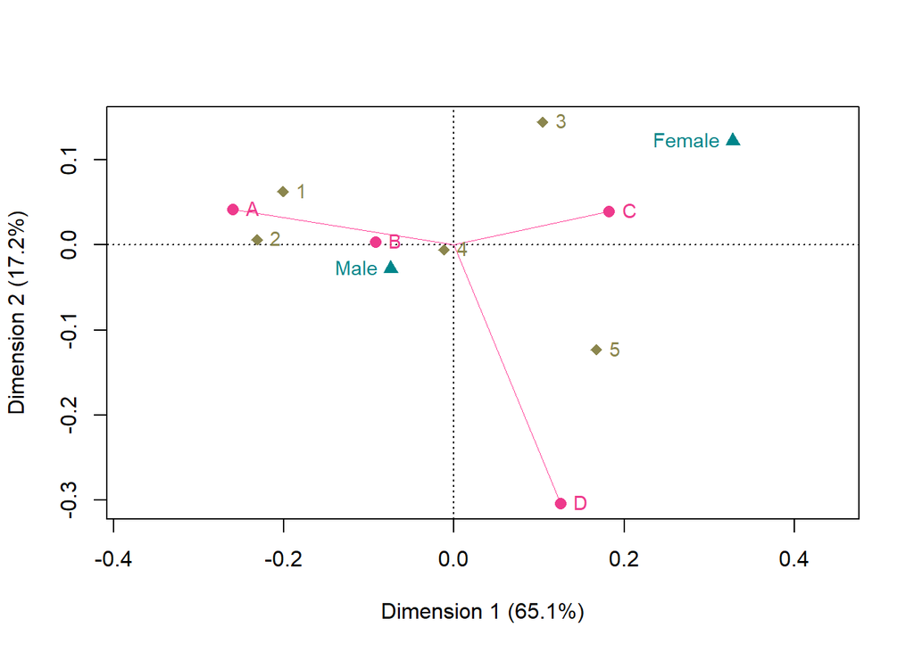

*This plot is not as informative as the stacked table because it does not reveal the clustering of all female responses around “C” and the trend to move from “A” -> “D” for males as they get older.*

## 6.12

Refer to Exercise 5.9 for a description of the Accident data set in vcdExtra. The data set is in the form of a frequency data frame, so first convert to table form.

1. Use mjca() to carry out an MCA on the four-way table accident.tab.

```
##
## Principal inertias (eigenvalues):
##
##  dim    value      %   cum%   scree plot
##  1      0.025429  46.5  46.5  ****************
##  2      0.011848  21.7  68.1  *******
##  3      0.001889   3.5  71.6  *
##  4      0.000491   0.9  72.5
##         -------- -----
##  Total: 0.054700
##
##
## Columns:
##                 name   mass  qlt  inr    k=1 cor ctr    k=2 cor ctr
## 1  |         age:0-9 |   13  672  107 |  551 561 152 | -246 111  65 |
## 2  |       age:10-19 |   49  678   91 |   40  13   3 |  292 665 354 |
## 3  |       age:20-29 |   56  784   85 | -215 747 102 |  -48  37  11 |
## 4  |       age:30-49 |   76  546   75 | -103 396  32 |  -63 149  26 |
## 5  |         age:50+ |   56  687   85 |  196 616  84 |  -67  72  21 |
## 6  |     result:Died |   11  515  100 |   90  92   3 | -192 422  34 |
## 7  |  result:Injured |  239  515    5 |   -4  92   0 |    9 422   2 |
## 8  |  mode:4-Wheeled |   81  230   73 |    8   2   0 |  -80 228  43 |
## 9  |    mode:Bicycle |   31  762   98 |  156 127  30 |  349 635 320 |
## 10 | mode:Motorcycle |   99  686   70 | -209 684 170 |   11   2   1 |
## 11 | mode:Pedestrian |   38  677  100 |  401 600 241 | -144  77  66 |
## 12 |   gender:Female |   77  788   77 |  203 686 126 |   78 101  40 |
## 13 |     gender:Male |  173  788   35 |  -91 686  56 |  -35 101  18 |
```

2. Construct an informative 2D plot of the solution, and interpret in terms of how the variable result varies in relation to the other factors.

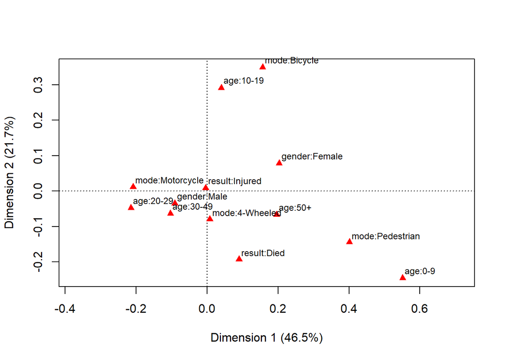

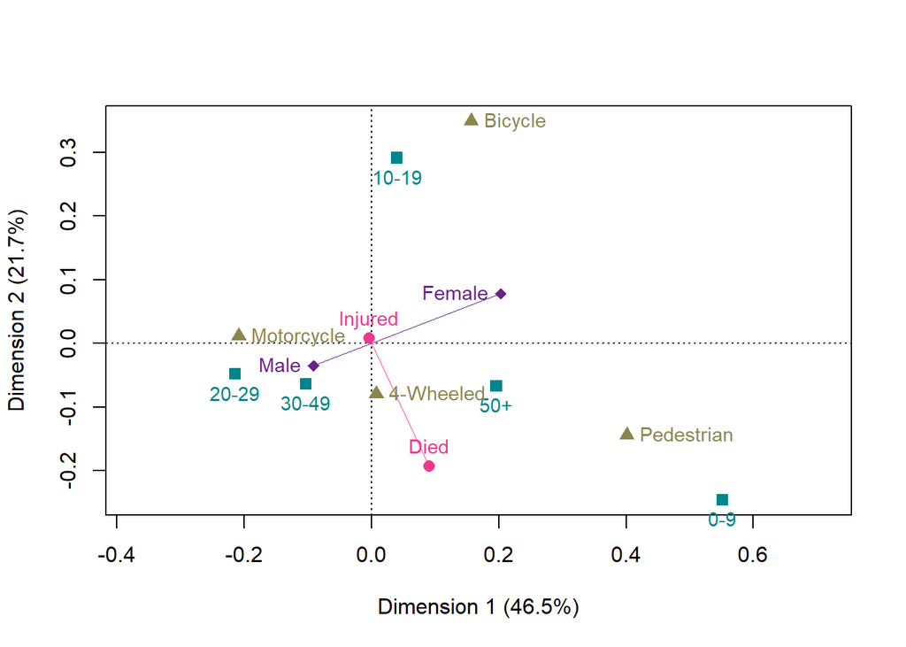

*This plot shows that there is little association between gender and result. The connecting lines are orthogonal, though the distances differ.*

*There appears to be a relationship between the 50+ age group and death results rather than injuries, as was seen in the previous chapter.*

*Males, especially those aged between 20-49 seem to be the group having the most accidents on motorcycles. Uncertain if they results in more injury than death.*

*There is a clustering between young women (age 10-19) and bicycle accidents.*

## 6.13

The UCBAdmissions data was featured in numerous examples in Chapter 4 (e.g., Example 4.11, Example 4.15) and Chapter 5 (e.g., Example 5.14, Example 5.18).

1. Use mjca () to carry out an MCA on the three-way table UCBAdmissions.

```
##
## Principal inertias (eigenvalues):
##
##  dim    value      %   cum%   scree plot
##  1      0.114945  80.5  80.5  ************************
##  2      0.005694   4.0  84.5  *
##  3      00000000   0.0  84.5
##  4      00000000   0.0  84.5
##  5      00000000   0.0  84.5
##         -------- -----
##  Total: 0.142840
##
##
## Columns:
##                name   mass  qlt  inr    k=1 cor ctr    k=2 cor ctr
## 1  | Admit:Admitted |  129  911   93 |  365 875 150 |   74  36 123 |
## 2  | Admit:Rejected |  204  911   59 | -231 875  95 |  -47  36  78 |
## 3  |  Gender:Female |  135  863   95 | -399 845 187 |   59  19  84 |
## 4  |    Gender:Male |  198  863   65 |  272 845 127 |  -40  19  57 |
## 5  |         Dept:A |   69  838  117 |  512 837 156 |   13   1   2 |
## 6  |         Dept:B |   43  829  124 |  573 824 123 |  -45   5  15 |
## 7  |         Dept:C |   68  731  108 | -270 594  43 |  130 137 199 |
## 8  |         Dept:D |   58  832  106 | -110 828   6 |    7   3   0 |
## 9  |         Dept:E |   43  812  117 | -384 787  55 |   69  25  35 |
## 10 |         Dept:F |   53  737  116 | -355 547  58 | -210 190 406 |
```

2. Plot the 2D MCA solution in a style similar to that shown in Figure 6.10 and Figure 6.11

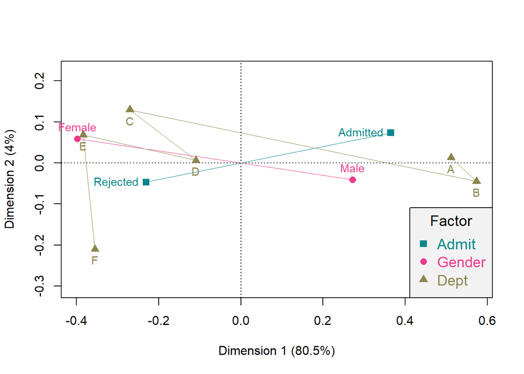

3. Interpret the plot. Is there some interpretation for the first dimension? What does the plot show about the relation of admission to the other factors?

*The first dimension separates both Admitted and Gender = Male, as well as Depts A & B. Given all the previous work with this dataset, this can be related to the high number of male applications to departments A & B which also have high acceptance rates. The reverse of these observations are seen on the left side of the dimension.*